# 以勒查经 《父母与子女》

25 July, 2020

## 问题

## 父母合神心意的教导

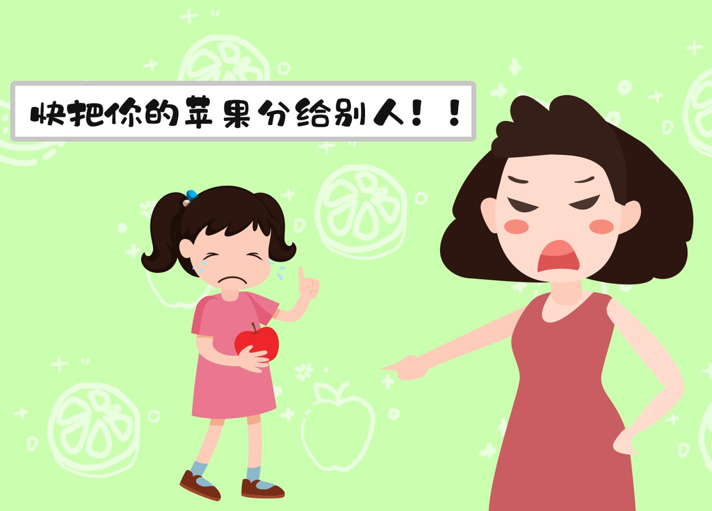

- 你认為神要父母教导孩子些什麼？
- 圣经说父母要教导儿女哪些内容(第1-7章)？

## 不要随从引诱、行暴力、贪财

[output not shown]

## 寻求智慧

[output not shown]

## 敬畏依靠耶和华

[output not shown]

## 保守你的心、口、眼睛、腳步，远离恶事

[output not shown]

## 远离淫妇

[output not shown]

## 父母的责任

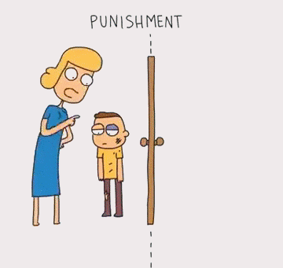

| 和合本 | ESV |
| --- | --- |
| 箴 13:24 不忍用杖打儿子的，是恨恶他；疼爱儿子的，随时管教。 | Proverbs 13:24 Whoever spares the rod hates his son, but he who loves him is diligent to discipline him. |
| 箴 19:18 趁有指望，管教你的儿子；你的心不可任他死亡。 | Proverbs 19:18 Discipline your son, for there is hope; do not set your heart on putting him to death. |
| 箴 22:6 教养孩童，使他走当行的道，就是到老他也不偏离。 | Proverbs 22:6 Train up a child in the way he should go; even when he is old he will not depart from it. |
| 箴 22:15 愚蒙迷住孩童的心，用管教的杖可以远远赶除。 | Proverbs 22:15 Folly is bound up in the heart of a child, but the rod of discipline drives it far from him. |
| 箴 23:13 不可不管教孩童；你用杖打他，他必不至於死。 | Proverbs 23:13 Do not withhold discipline from a child; if you strike him with a rod, he will not die. |
| 箴 29:15 杖打和责备能加增智慧；放纵的儿子使母亲羞愧。 | Proverbs 29:15 The rod and reproof give wisdom, but a child left to himself brings shame to his mother. |
| 箴 29:17 管教你的儿子，他就使你得安息，也必使你心裡喜乐。 | Proverbs 29:17 Discipline your son, and he will give you rest; he will give delight to your heart. |

**问题(请点击)**

- 对於教养儿女，父母有什麼该做和不该做的？為什麼？
- 应该从什麼时候开始管教？為什麼如此的重要？
- 现今西方社会不容许体罚，父母应该用什麼方法管教儿女？
- 分享一下被父母管教的经歷，有什麼深刻印象、对你有什麼影响？

## 问卷调查

[figure not shown]

- 问卷：https://forms.gle/E6EyMsD2gEGK3CWY7
- 结果：https://bit.ly/3jy2DXM

## 子女的责任

| 和合本 | ESV |
| --- | --- |
| 箴 1:8-9 我儿，要听你父亲的训诲，不可离弃你母亲的法则（或译：指教）， 因为这要做你头上的华冠，你项上的金链。 | Proverbs 1:8-9 Hear, my son, your father's instruction, and forsake not your mother's teaching, for they are a graceful garland for your head and pendants for your neck. |
| 箴 4:1-2 眾子啊，要听父亲的教训，留心得知聪明。因我所给你们的是好教训；不可离弃我的法则（或译：指教）。 | Proverbs 4:1-2 [ A Father's Wise Instruction ] Hear, O sons, a father's instruction, and be attentive, that you may gain insight, for I give you good precepts; do not forsake my teaching. |
| 箴 4:3-4 我在父亲面前為孝子，在母亲眼中為独一的娇儿。父亲教训我说：你心要存记我的言语，遵守我的命令，便得存活。 | Proverbs 4:3-4 When I was a son with my father, tender, the only one in the sight of my mother, he taught me and said to me,“Let your heart hold fast my words; keep my commandments, and live. |
| 箴 6:20-21 20 我儿，要谨守你父亲的诫命，不可离弃你母亲的法则（或译：指教）， 21 要常系在你心上，挂在你项上。 | Proverbs 6:20-21 My son, keep your father's commandment, and forsake not your mother's teaching. 21 Bind them on your heart always; tie them around your neck. |
| 箴 13:1 智慧子听父亲的教训；褻慢人不听责备。 | Proverbs 13:1 A wise son hears his father's instruction, but a scoffer does not listen to rebuke. |
| 箴 15:5 愚妄人藐视父亲的管教；领受责备的，得著见识。 | Proverbs 15:5 A fool despises his father's instruction, but whoever heeds reproof is prudent. |
| 箴 23:22 你要听从生你的父亲；你母亲老了，也不可藐视她。 | Proverbs 23:22 Listen to your father who gave you life, and do not despise your mother when she is old. |

## 子女的责任

[figure not shown]

- 经文教导我们该如何看待父母的教训？
- 听从和遵从父母的教训有什麼好处？不这样做有什麼坏处？
- 什麼原因使我们不愿意听父母的话？你这样做父母有什么感受？

## 子女该如何对待父母

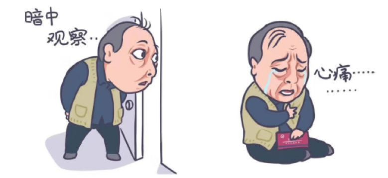

| 和合本 | ESV |
| --- | --- |
| 箴 10:1 所罗门的箴言：智慧之子使父亲欢乐；愚昧之子叫母亲担忧。 | Proverbs 10:1 [ The Proverbs of Solomon ] The proverbs of Solomon. A wise son makes a glad father, but a foolish son is a sorrow to his mother. |
| 箴 15:20 智慧子使父亲喜乐；愚昧人藐视母亲。 | Proverbs 15:20 A wise son makes a glad father, but a foolish man despises his mother. |
| 箴 17:21 生愚昧子的，必自愁苦；愚顽人的父毫无喜乐。 | Proverbs 17:21 He who sires a fool gets himself sorrow, and the father of a fool has no joy. |
| 箴 17:25 愚昧子使父亲愁烦，使母亲忧苦。 | Proverbs 17:25 A foolish son is a grief to his father and bitterness to her who bore him. |
| 箴 19:13 愚昧的儿子是父亲的祸患；妻子的争吵如雨连连滴漏。 | Proverbs 19:13 A foolish son is ruin to his father, and a wife's quarreling is a continual dripping of rain. |
| 箴 19:26 虐待父亲、撵出母亲的，是貽羞致辱之子。 | Proverbs 19:26 He who does violence to his father and chases away his mother is a son who brings shame and reproach. |
| 箴 20:20 咒骂父母的，他的灯必灭，变為漆黑的黑暗。 | Proverbs 20:20 If one curses his father or his mother, his lamp will be put out in utter darkness. |
| 箴 23:22 你要听从生你的父亲；你母亲老了，也不可藐视她。 | Proverbs 23:22 Listen to your father who gave you life, and do not despise your mother when she is old. |
| 箴 23:24 义人的父亲必大得快乐；人生智慧的儿子，必因他欢喜。 | Proverbs 23:24 The father of the righteous will greatly rejoice; he who fathers a wise son will be glad in him. |
| 箴 23:25 你要使父母欢喜，使生你的快乐。 | Proverbs 23:25 Let your father and mother be glad; let her who bore you rejoice. |

[output cut: 4 more lines]

**问题(请点击)**

- 神喜悦我们如何对待父母？
- 怎麼样算是恶待、善待父母，他们分别被称為什麼人？恶待父母有什麼后果？
- 什么原因会使儿女恶待(藐视，戏笑，咒骂，虐待)、善待(使父母喜乐，祝福父母，听从父母) 父母？
- 目前你们有特意为父母做什么事情是使他们愉快，而不使他们愁烦？

## 应用问题

- 如果父母反对你的对象，因为对方条件不够好，你应该怎样回应才合神心意？
- 如果父母教你的是违背圣经的，你会如何处理？

## 结论

- 作父母的要以神的话语和训诲来教导孩子，他们不会走上败坏的道路。
- 应当趁孩子年幼的时候管教他们，不要过分宠爱儿女，他们才不会愚昧地生活。
- 父母有合神心意的教导，作儿女的要学习听从和遵行，因为听教导的得著见识、得存活(益处)，不听的话会走歪路(坏处)。
- 我们要学习去尊敬父母、善待他们、使他们喜乐，因為恶待父母的不会有好结果。

## 金句

### 箴 10:1 所羅門的箴言：智慧之子使父親歡樂；愚昧之子叫母親擔憂。

## 全部经文

[output not shown]

[output cut: 28 more lines]